# Informational Interview with Nelson Malugu

Jackine Nkoma

2025-05-05

# Informational Interview with Nelson Malugu

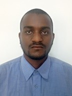

**Introduction** In this informational interview, I got an opportunity to talk with Nelson Malugu, an epidemiologist from Tanzania field epidemiology and laboratory training program (FELTP). Specifically focusing on outbreak investigations and surveillance activities, including responding to public health emergencies. With additional to teaching and mentoring of field epidemiology trainee and residence.

## Background

**Tells us more about your background and previous achievement**

Nelson started his career as a medical laboratory scientist at the Mbeya referral hospital, working in the molecular biology sections, Testing for HIV drug resistance sample and HIV viral load sample. He pursued his Master of Science in Epidemiology and Laboratory Management at Muhimbili University Health and Allied Science. As an epidemiologist, he had worked with AMREF Africa on a global Health security agenda project. Generally, he achieved to support Mbeya Zonal reference lab to achieve its accreditation. Also, he Supported the field epidemiology training program and acquired two Publications.

**What encourage you to enter in epidemiology field?**

It all started from his undergraduate studies, from his participation on their project of Extended Spectrum bitter lactam negative bacteria form Post-delivery women to neonate at Buganda Medical Center. So when he wanted to pursue a graduate study, he tried to look for a course which can add some research skills. Since his long term plan is to become an expert in how to break investigation and surveillance, he decided to choose epidemiology.

## Epidemiologist roles and responsibilities

**What are the roles and responsibility of an epidemiologist.**

Nelson highlighted that conducting surveillance and responded to public health emergencies are the main roles and responsibilities of an epidemiologist. Which also include data collection, analysis, interpretation and reporting findings. For the starting point, an epidemiologist has possess at least an intermediate level skill on data management and analysis. But to become a more competent, an epidemiologist should improve his/ her data management and analysis skills. Additionally, due to the current situation, he/she needs to know how to use programming language software’s like R-programming and python. Which means, an epidemiologist should also have data science skills especially modelling and prediction of outbreaks, or outbreak analysis. Moreover, they need to have artificial intelligence (AI) skill since currently AI take place in most of the activities.

## Experience working on malaria area

**Have you ever worked on malaria data.**

As an epidemiologist, Nelson worked on malaria area when he was a resident at FELTP. Where he got an opportunity to work with Mwanza regional management team and JAPHAIGO on malaria service data quality improvement (MSDQI) at Buchosa District. He also supervised and mentored FELTP residence conducting malaria survey aiming to determine the prevalence of Malaria for School children, and the risk factors associated with malaria for school children, in Dar es Salaam and Tanga region. They did not publish it, but they did prepare a manuscript to submit to the journals for publication.

## Research interest

**Have you ever had an interest on malaria as a research area?**

Nelson’s research interest is on emerging and reemerging disease, also interested on drug resistance for malaria and other microbes. He is also interested on modelling for different infectious diseases, especially emerging and reemerging diseases, including geo-spatial modelling. Due to that, he started some online courses like kozera and UDEM which are free accessible.

## Future of epidemiology field

**In future, were do you see epidemiology field**

According to Nelson, since we anticipate future pandemic (like viral hemorrhagic fever, emerging and reemerging diseases) still epidemiologist will be needed. Despite the presence of AI in participating to certain activities, an epidemiologist will still be need to respond public health emergency. The increase in the number of people in other imaging field like data scientist can also increase competition in epidemiology field. So an epidemiologist has to be well skilled on the use of programming language, also data science and AI as whole for him/her to be competitive. So the challenge that epidemiologist are going to face in future, is a lack of data science, artificial intelligence or programming language skills.

## Difference between epidemiology, biostatistics, and health statistics

**Can you please differentiate between epidemiology, biostatistics, and health statistics?**

He differentiated them by highlighting their scope, where Biostatistics and health statistics they are part of epidemiology. Being an epidemiologist its more of a field and a data person, while biostatistics and health statistics its more of a data person, rather than being a field person.

## Career development

**Did you plan to go for the further studies?**

He planned to go for further studies, especially focusing on Bio-medical data science and health informatics, since he is interested in big data analytics. Since working with those bio-medical health data allows him to combine Biology and Data science.

## Advice to juniors

**What would you advise the juniors who would wish to enter in data field? Would also like to be the data expert.**

His advice is to start early. The moment you know you are interested in data science or big data analytics or epidemiology, you have to start working on it. There are courses online which are free such as kozera, UDEM, there are W3 school for programming language. You just need to start learning because the material is available for free. And you can learn anything you want to learn, so my advice is to start early.

**What do you wish you had known before entering the Filled?**

He wished to have a very strong Foundation in Statistics, focusing on biostatistics. But also, Start working with data, learning through practicing with data early. So at the end you have both, a good foundation of statistics, plus a practical part of working with data. For high school or secondary student, they need to understand their interest early. If someone is interested in data science, epidemiology, or any other fields, they should focus on their interest. They need to develop their interest early, don’t wait until late. Generally, his advice is to work hard, to search for opportunities, because opportunities are so many. The world will not deprive in opportunities, So just to try for opportunities and trust in God.

## Recommendation on who to speak to

**Would you Recommend to anyone you wish I could talk too?**

He recommended expert or people who are working on malaria projects at Ifakara health institute, thinking they have a lot of information in term of malaria and data. Also data scientist, biomedical scientist, clinicians who are on malaria project at Ifakara health institute. But also researchers from NIMR who are working on malaria.